# UB01A6

Anatol

3/20/2022

# Aufgabe 6

```r
psycho <- read.table("psycho.txt", sep = " ")
head(psycho)
```

| gpa | iq | alter | sex | total | c1 | c2 | c3 | c4 | c5 | c6 |
| --- | --- | --- | --- | --- | --- | --- | --- | --- | --- | --- |
| 7.940 | 111 | 13 | 2 | 67 | 15 | 17 | 13 | 13 | 11 | 9 |
| 8.292 | 107 | 12 | 2 | 43 | 12 | 12 | 7 | 7 | 6 | 6 |
| 4.643 | 100 | 13 | 2 | 52 | 11 | 10 | 5 | 8 | 9 | 7 |
| 7.470 | 107 | 12 | 2 | 66 | 14 | 15 | 11 | 11 | 9 | 9 |
| 8.882 | 114 | 12 | 1 | 58 | 14 | 15 | 10 | 12 | 11 | 6 |
| 7.585 | 115 | 12 | 2 | 51 | 14 | 11 | 7 | 8 | 6 | 9 |

```r
str(psycho)
```

```
## 'data.frame':    78 obs. of  11 variables:
##  $ gpa  : num  7.94 8.29 4.64 7.47 8.88 ...
##  $ iq   : int  111 107 100 107 114 115 111 97 100 112 ...
##  $ alter: int  13 12 13 12 12 12 13 13 13 13 ...
##  $ sex  : int  2 2 2 2 1 2 2 2 1 2 ...
##  $ total: int  67 43 52 66 58 51 71 51 49 51 ...
##  $ c1   : int  15 12 11 14 14 14 15 10 12 15 ...
##  $ c2   : int  17 12 10 15 15 11 17 12 9 16 ...
##  $ c3   : int  13 7 5 11 10 7 12 5 6 4 ...
##  $ c4   : int  13 7 8 11 12 8 14 11 9 9 ...
##  $ c5   : int  11 6 9 9 11 6 11 5 6 5 ...
##  $ c6   : int  9 6 7 9 6 9 10 6 7 8 ...
```

```r
summary(psycho)
```

```
##       gpa               iq            alter            sex
##  Min.   : 0.530   Min.   : 72.0   Min.   :12.00   Min.   :1.000
##  1st Qu.: 6.278   1st Qu.:103.0   1st Qu.:12.00   1st Qu.:1.000
##  Median : 7.829   Median :110.0   Median :13.00   Median :2.000
##  Mean   : 7.447   Mean   :108.9   Mean   :12.74   Mean   :1.603
##  3rd Qu.: 8.983   3rd Qu.:117.5   3rd Qu.:13.00   3rd Qu.:2.000
##  Max.   :10.760   Max.   :136.0   Max.   :15.00   Max.   :2.000
##      total             c1              c2              c3
##  Min.   :20.00   Min.   : 4.00   Min.   : 2.00   Min.   : 1.000
##  1st Qu.:51.00   1st Qu.:12.00   1st Qu.:11.00   1st Qu.: 6.000
##  Median :59.50   Median :14.00   Median :13.00   Median : 8.000
##  Mean   :56.96   Mean   :13.03   Mean   :12.54   Mean   : 8.115
##  3rd Qu.:66.00   3rd Qu.:15.00   3rd Qu.:15.75   3rd Qu.:11.000
##  Max.   :80.00   Max.   :16.00   Max.   :17.00   Max.   :13.000
##        c4               c5               c6
##  Min.   : 2.000   Min.   : 1.000   Min.   : 1.000
##  1st Qu.: 8.000   1st Qu.: 6.000   1st Qu.: 7.000
##  Median :10.500   Median : 9.000   Median : 8.500
##  Mean   : 9.795   Mean   : 7.936   Mean   : 8.051
##  3rd Qu.:12.000   3rd Qu.:10.000   3rd Qu.:10.000
##  Max.   :14.000   Max.   :12.000   Max.   :10.000
```

## 6a)

*Schauen Sie sich den Datensatz genauer an. Deﬁnieren Sie die kategorialen Variablen als factor.*

```r
psycho$sex <- as.factor(psycho$sex)
str(psycho)
```

```
## 'data.frame':    78 obs. of  11 variables:
##  $ gpa  : num  7.94 8.29 4.64 7.47 8.88 ...
##  $ iq   : int  111 107 100 107 114 115 111 97 100 112 ...
##  $ alter: int  13 12 13 12 12 12 13 13 13 13 ...
##  $ sex  : Factor w/ 2 levels "1","2": 2 2 2 2 1 2 2 2 1 2 ...
##  $ total: int  67 43 52 66 58 51 71 51 49 51 ...
##  $ c1   : int  15 12 11 14 14 14 15 10 12 15 ...
##  $ c2   : int  17 12 10 15 15 11 17 12 9 16 ...
##  $ c3   : int  13 7 5 11 10 7 12 5 6 4 ...
##  $ c4   : int  13 7 8 11 12 8 14 11 9 9 ...
##  $ c5   : int  11 6 9 9 11 6 11 5 6 5 ...
##  $ c6   : int  9 6 7 9 6 9 10 6 7 8 ...
```

## 6b)

*Gehen Sie vom vollen Modell aus (ohne Interaktionsterme) und wenden Sie die Ruckwartselimination auf das Modell an. D.h. passen Sie das Modell an und eliminieren Sie dann die Variable mit dem hochsten p-Wert uber dem gewahlten Signiﬁkanzniveau (5%). Wiederholen Sie diese Vorgehensweise so lange, bis nur noch Variablen mit signiﬁkanten Parametern im Modell enthalten sind. Welches beste Modell erhalten Sie?*

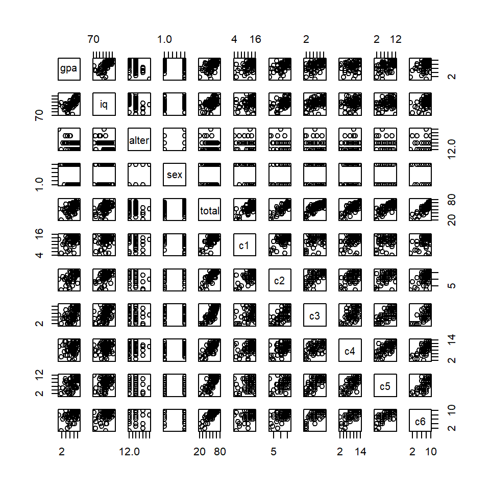

```r
pairs(psycho)
```

```r
sel_model <- lm(gpa ~ ., data = psycho)
summary(sel_model)
```

```
##
## Call:
## lm(formula = gpa ~ ., data = psycho)
##
## Residuals:
##     Min      1Q  Median      3Q     Max
## -4.7041 -0.5908  0.1236  0.8978  2.6421
##
## Coefficients:
##              Estimate Std. Error t value Pr(>|t|)
## (Intercept)  2.520984   4.643587   0.543   0.5890
## iq           0.073391   0.017552   4.181  8.6e-05 ***
## alter       -0.410206   0.292001  -1.405   0.1647
## sex2        -0.575293   0.394721  -1.457   0.1497
## total       -0.066639   0.058707  -1.135   0.2604
## c1           0.188234   0.111042   1.695   0.0947 .
## c2           0.128614   0.089070   1.444   0.1534
## c3           0.122059   0.095523   1.278   0.2057
## c4          -0.003139   0.113448  -0.028   0.9780
## c5           0.142544   0.106541   1.338   0.1854
## c6           0.018150   0.167195   0.109   0.9139
## ---
## Signif. codes:  0 '***' 0.001 '**' 0.01 '*' 0.05 '.' 0.1 ' ' 1
##
## Residual standard error: 1.441 on 67 degrees of freedom
## Multiple R-squared:  0.5903, Adjusted R-squared:  0.5291
## F-statistic: 9.653 on 10 and 67 DF,  p-value: 9.589e-10
```

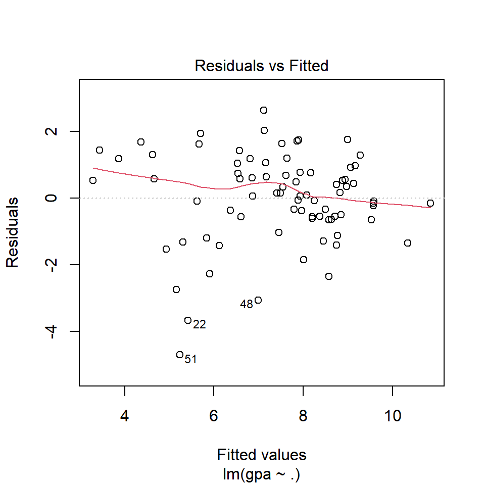

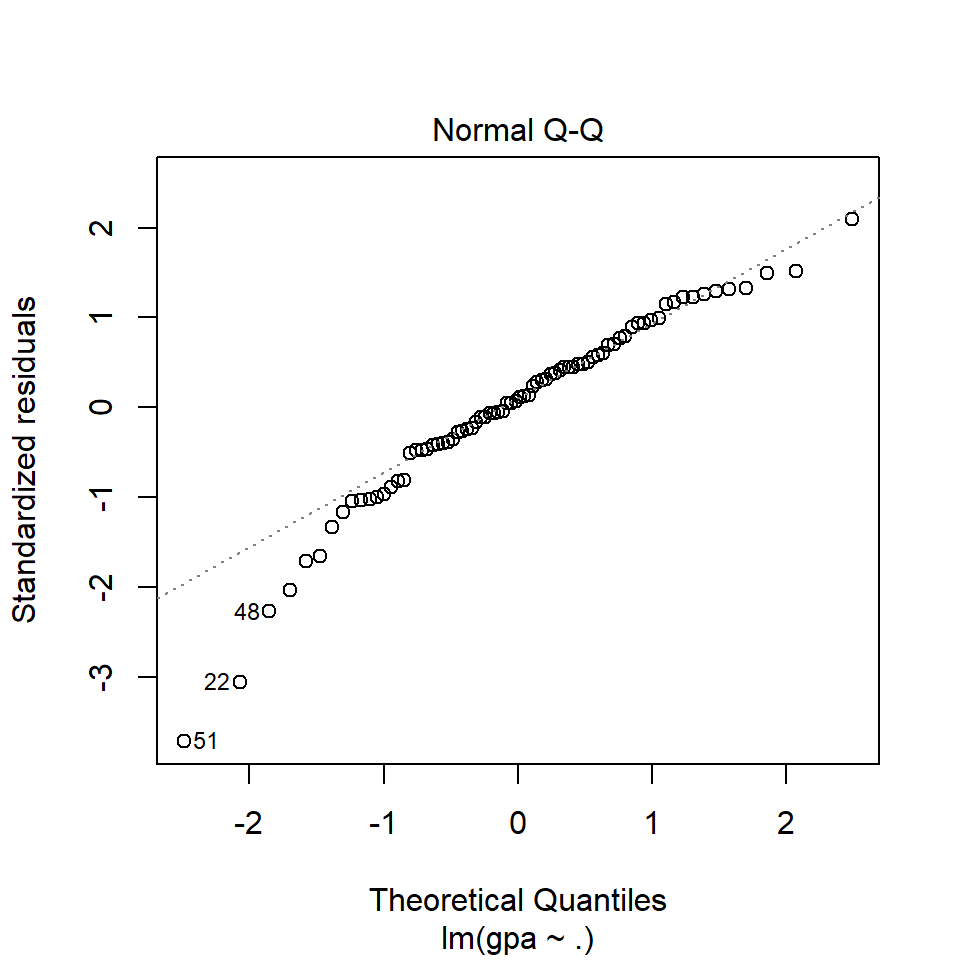

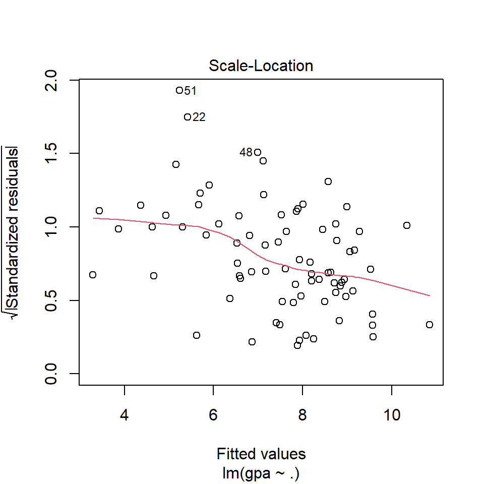

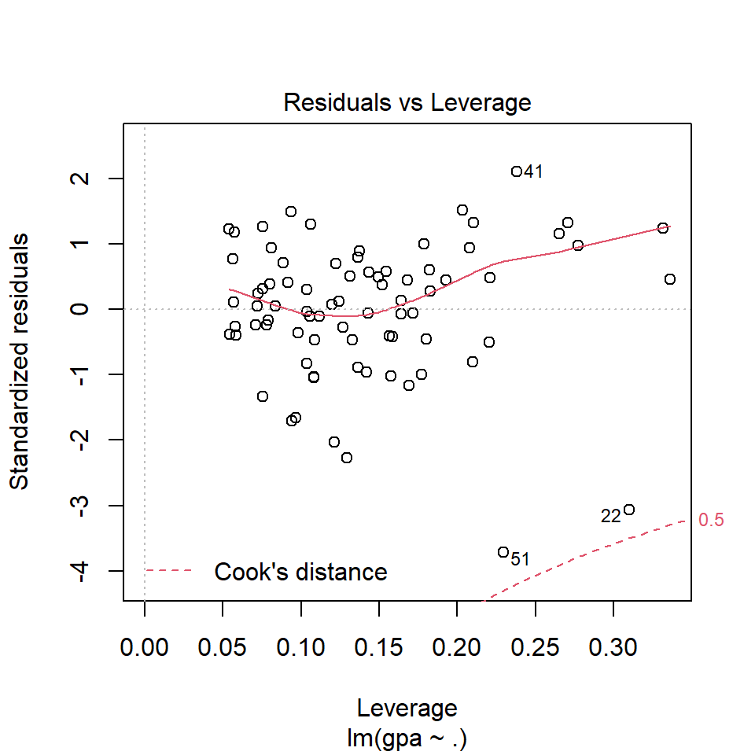

```r
plot(sel_model)
```

```r
back_01 <- update(sel_model, . ~. - c4)
summary(back_01)
```

```
##
## Call:
## lm(formula = gpa ~ iq + alter + sex + total + c1 + c2 + c3 +
##     c5 + c6, data = psycho)
##
## Residuals:
##     Min      1Q  Median      3Q     Max
## -4.7054 -0.5916  0.1265  0.8970  2.6392
##
## Coefficients:
##             Estimate Std. Error t value Pr(>|t|)
## (Intercept)  2.51747    4.60762   0.546   0.5866
## iq           0.07355    0.01641   4.484  2.9e-05 ***
## alter       -0.41080    0.28906  -1.421   0.1598
## sex2        -0.57815    0.37814  -1.529   0.1309
## total       -0.06747    0.05007  -1.348   0.1823
## c1           0.18931    0.10330   1.833   0.0712 .
## c2           0.12860    0.08841   1.455   0.1504
## c3           0.12282    0.09083   1.352   0.1808
## c5           0.14199    0.10386   1.367   0.1761
## c6           0.01765    0.16500   0.107   0.9151
## ---
## Signif. codes:  0 '***' 0.001 '**' 0.01 '*' 0.05 '.' 0.1 ' ' 1
##
## Residual standard error: 1.43 on 68 degrees of freedom
## Multiple R-squared:  0.5903, Adjusted R-squared:  0.5361
## F-statistic: 10.89 on 9 and 68 DF,  p-value: 2.785e-10
```

```r
back_02 <- update(back_01, . ~. - c6)
summary(back_02)
```

```
##
## Call:
## lm(formula = gpa ~ iq + alter + sex + total + c1 + c2 + c3 +
##     c5, data = psycho)
##
## Residuals:
##     Min      1Q  Median      3Q     Max
## -4.7082 -0.5840  0.1278  0.8815  2.6435
##
## Coefficients:
##             Estimate Std. Error t value Pr(>|t|)
## (Intercept)  2.47444    4.55704   0.543   0.5889
## iq           0.07353    0.01629   4.515 2.54e-05 ***
## alter       -0.40666    0.28440  -1.430   0.1573
## sex2        -0.57486    0.37418  -1.536   0.1290
## total       -0.06493    0.04378  -1.483   0.1426
## c1           0.18922    0.10256   1.845   0.0693 .
## c2           0.12618    0.08485   1.487   0.1416
## c3           0.12419    0.08927   1.391   0.1686
## c5           0.14316    0.10254   1.396   0.1672
## ---
## Signif. codes:  0 '***' 0.001 '**' 0.01 '*' 0.05 '.' 0.1 ' ' 1
##
## Residual standard error: 1.42 on 69 degrees of freedom
## Multiple R-squared:  0.5902, Adjusted R-squared:  0.5427
## F-statistic: 12.42 on 8 and 69 DF,  p-value: 7.587e-11
```

```r
back_03 <- update(back_02, . ~. - c3)
summary(back_03)
```

```
##
## Call:
## lm(formula = gpa ~ iq + alter + sex + total + c1 + c2 + c5, data = psycho)
##
## Residuals:
##     Min      1Q  Median      3Q     Max
## -4.6407 -0.6757  0.1814  1.0390  2.3828
##
## Coefficients:
##             Estimate Std. Error t value Pr(>|t|)
## (Intercept)  2.07314    4.57818   0.453   0.6521
## iq           0.07363    0.01639   4.491 2.72e-05 ***
## alter       -0.39740    0.28622  -1.388   0.1694
## sex2        -0.58496    0.37660  -1.553   0.1249
## total       -0.03803    0.03954  -0.962   0.3394
## c1           0.13970    0.09682   1.443   0.1535
## c2           0.14068    0.08477   1.659   0.1015
## c5           0.17050    0.10131   1.683   0.0968 .
## ---
## Signif. codes:  0 '***' 0.001 '**' 0.01 '*' 0.05 '.' 0.1 ' ' 1
##
## Residual standard error: 1.429 on 70 degrees of freedom
## Multiple R-squared:  0.5787, Adjusted R-squared:  0.5366
## F-statistic: 13.74 on 7 and 70 DF,  p-value: 4.778e-11
```

```r
back_04 <- update(back_03, . ~. - total)
summary(back_04)
```

```
##
## Call:
## lm(formula = gpa ~ iq + alter + sex + c1 + c2 + c5, data = psycho)
##
## Residuals:
##     Min      1Q  Median      3Q     Max
## -4.6629 -0.6746  0.1587  1.0172  2.2103
##
## Coefficients:
##             Estimate Std. Error t value Pr(>|t|)
## (Intercept)  2.69559    4.52983   0.595   0.5537
## iq           0.07054    0.01607   4.390 3.87e-05 ***
## alter       -0.44315    0.28209  -1.571   0.1206
## sex2        -0.71313    0.35205  -2.026   0.0466 *
## c1           0.08420    0.07770   1.084   0.2822
## c2           0.09873    0.07265   1.359   0.1785
## c5           0.10207    0.07209   1.416   0.1612
## ---
## Signif. codes:  0 '***' 0.001 '**' 0.01 '*' 0.05 '.' 0.1 ' ' 1
##
## Residual standard error: 1.428 on 71 degrees of freedom
## Multiple R-squared:  0.5732, Adjusted R-squared:  0.5371
## F-statistic: 15.89 on 6 and 71 DF,  p-value: 1.754e-11
```

```r
back_05 <- update(back_04, . ~. - c1)
summary(back_05)
```

```
##
## Call:
## lm(formula = gpa ~ iq + alter + sex + c2 + c5, data = psycho)
##
## Residuals:
##     Min      1Q  Median      3Q     Max
## -4.4440 -0.6832  0.1313  0.9382  2.6267
##
## Coefficients:
##             Estimate Std. Error t value Pr(>|t|)
## (Intercept)  4.09734    4.34642   0.943   0.3490
## iq           0.06761    0.01586   4.264 6.01e-05 ***
## alter       -0.48095    0.28026  -1.716   0.0904 .
## sex2        -0.81135    0.34059  -2.382   0.0199 *
## c2           0.14211    0.06070   2.341   0.0220 *
## c5           0.10341    0.07217   1.433   0.1562
## ---
## Signif. codes:  0 '***' 0.001 '**' 0.01 '*' 0.05 '.' 0.1 ' ' 1
##
## Residual standard error: 1.43 on 72 degrees of freedom
## Multiple R-squared:  0.5661, Adjusted R-squared:  0.536
## F-statistic: 18.79 on 5 and 72 DF,  p-value: 6.633e-12
```

```r
back_06 <- update(back_05, . ~. - c5)
summary(back_06)
```

```
##
## Call:
## lm(formula = gpa ~ iq + alter + sex + c2, data = psycho)
##
## Residuals:
##     Min      1Q  Median      3Q     Max
## -4.6498 -0.6267  0.1500  0.8872  2.8434
##
## Coefficients:
##             Estimate Std. Error t value Pr(>|t|)
## (Intercept)  3.95541    4.37652   0.904  0.36908
## iq           0.06878    0.01595   4.312 4.99e-05 ***
## alter       -0.45913    0.28186  -1.629  0.10764
## sex2        -0.86383    0.34105  -2.533  0.01346 *
## c2           0.18910    0.05144   3.676  0.00045 ***
## ---
## Signif. codes:  0 '***' 0.001 '**' 0.01 '*' 0.05 '.' 0.1 ' ' 1
##
## Residual standard error: 1.44 on 73 degrees of freedom
## Multiple R-squared:  0.5537, Adjusted R-squared:  0.5293
## F-statistic: 22.64 on 4 and 73 DF,  p-value: 3.442e-12
```

```r
back_final <- update(back_06, . ~. - alter)
summary(back_final)
```

```
##
## Call:
## lm(formula = gpa ~ iq + sex + c2, data = psycho)
##
## Residuals:
##     Min      1Q  Median      3Q     Max
## -5.6098 -0.6634  0.1974  0.8625  3.0169
##
## Coefficients:
##             Estimate Std. Error t value Pr(>|t|)
## (Intercept) -2.80407    1.40606  -1.994 0.049807 *
## iq           0.07691    0.01532   5.021 3.44e-06 ***
## sex2        -0.90878    0.34371  -2.644 0.009997 **
## c2           0.19304    0.05196   3.715 0.000391 ***
## ---
## Signif. codes:  0 '***' 0.001 '**' 0.01 '*' 0.05 '.' 0.1 ' ' 1
##
## Residual standard error: 1.456 on 74 degrees of freedom
## Multiple R-squared:  0.5375, Adjusted R-squared:  0.5188
## F-statistic: 28.67 on 3 and 74 DF,  p-value: 2.088e-12
```

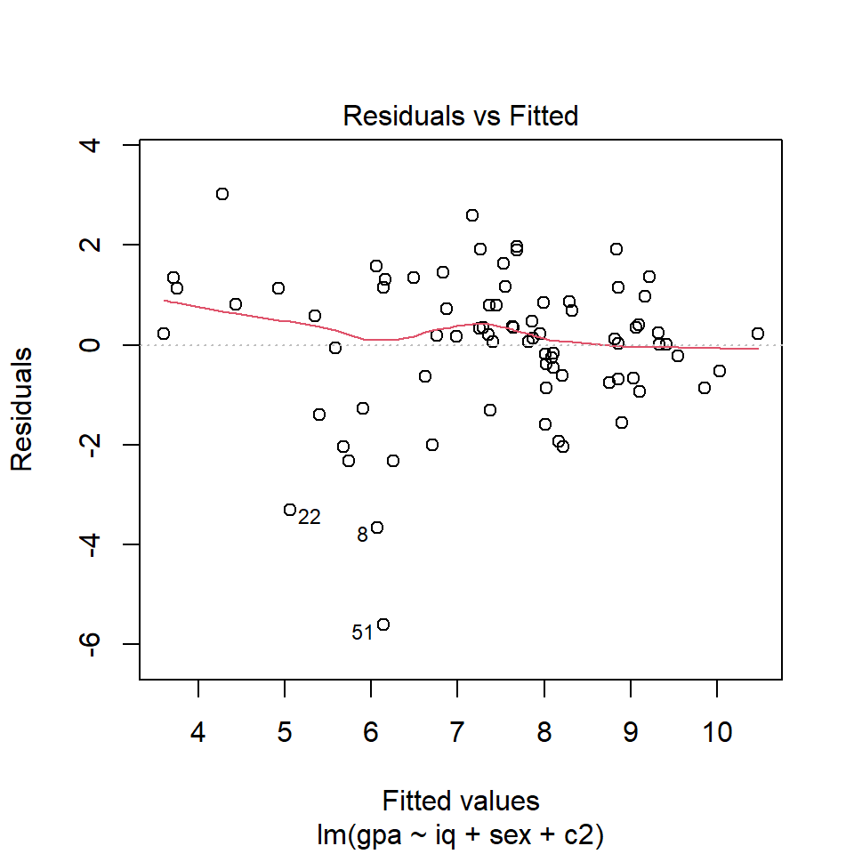

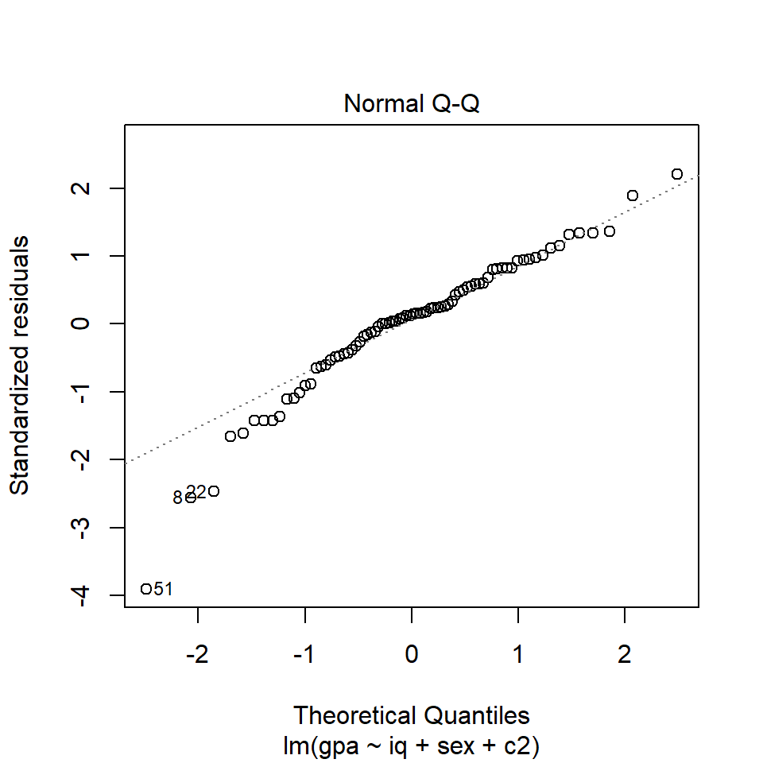

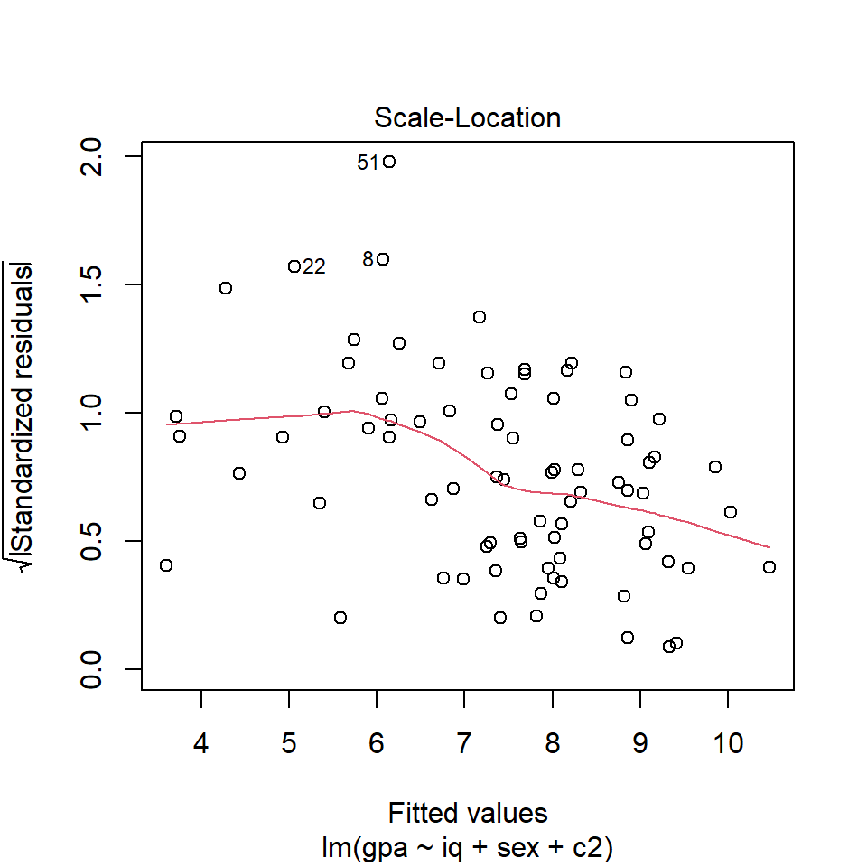

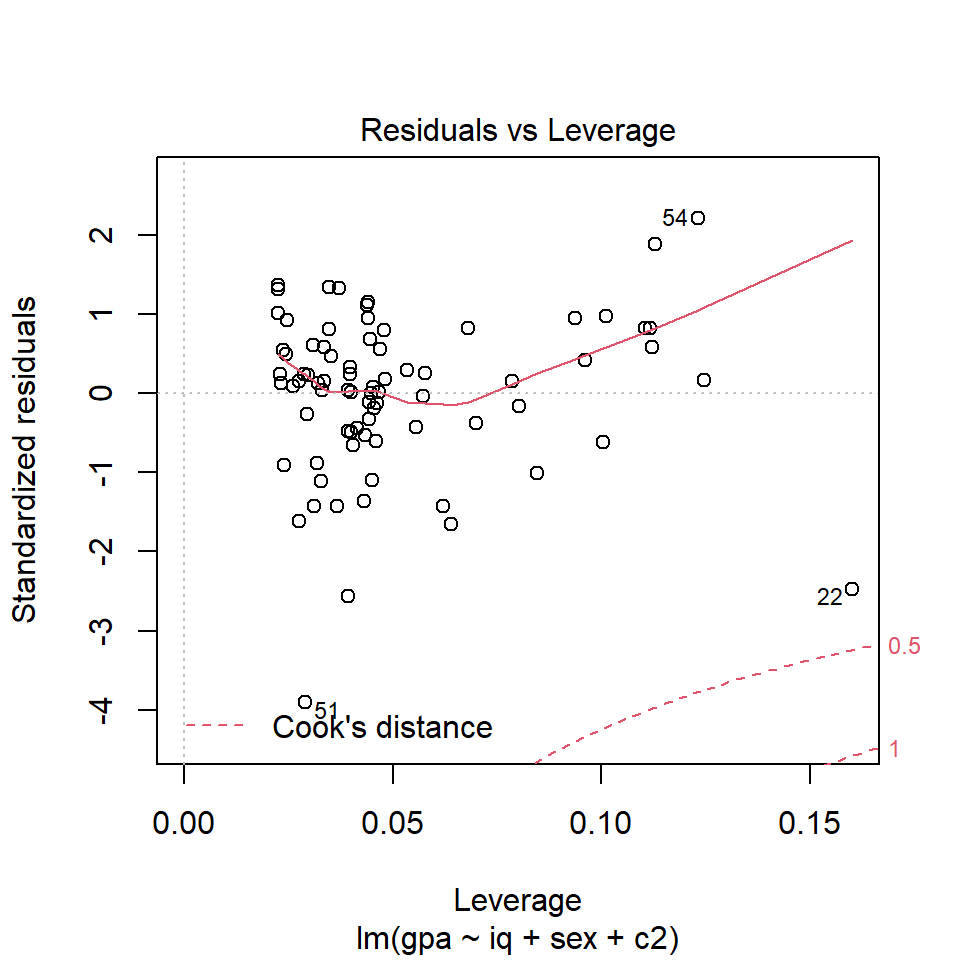

```r
plot(back_final)
```

Das beste Modell ist gpa = $β_0 + β_1*iq + β_2*sex + β_3*c2$ mit $R^2$ gleich 0.5375.

## 6c)

*Wenden Sie nun die schrittweise Selektion mit dem AIC (Funktion stepAIC aus dem Paket MASS in R) auf den Datensatz an. Achten Sie darauf, dass Sie die Argumente der Funktion stepAIC richtig deﬁnieren. Verwenden Sie dabei zunachst das volle Modell und dann das Nullmodell als Ausgangsmodell.*

```r
stepAIC(sel_model, direction = "both")
```

```
## Start:  AIC=67.1
## gpa ~ iq + alter + sex + total + c1 + c2 + c3 + c4 + c5 + c6
##
##         Df Sum of Sq    RSS    AIC
## - c4     1     0.002 139.07 65.103
## - c6     1     0.024 139.09 65.116
## - total  1     2.674 141.74 66.588
## - c3     1     3.389 142.45 66.980
## <none>               139.06 67.102
## - c5     1     3.715 142.78 67.158
## - alter  1     4.096 143.16 67.366
## - c2     1     4.328 143.39 67.492
## - sex    1     4.409 143.47 67.536
## - c1     1     5.964 145.03 68.377
## - iq     1    36.288 175.35 83.187
##
## Step:  AIC=65.1
## gpa ~ iq + alter + sex + total + c1 + c2 + c3 + c5 + c6
##
##         Df Sum of Sq    RSS    AIC
## - c6     1     0.023 139.09 63.116
## <none>               139.07 65.103
## - total  1     3.713 142.78 65.158
## - c3     1     3.739 142.81 65.172
## - c5     1     3.822 142.89 65.218
## - alter  1     4.130 143.20 65.386
## - c2     1     4.327 143.39 65.493
## - sex    1     4.781 143.85 65.739
## - c1     1     6.868 145.93 66.863
## + c4     1     0.002 139.06 67.102
## - iq     1    41.111 180.18 83.304
##
## Step:  AIC=63.12
## gpa ~ iq + alter + sex + total + c1 + c2 + c3 + c5
##
##         Df Sum of Sq    RSS    AIC
## <none>               139.09 63.116
## - c3     1     3.901 142.99 63.274
## - c5     1     3.929 143.02 63.289
## - alter  1     4.121 143.21 63.394
## - total  1     4.434 143.52 63.564
## - c2     1     4.458 143.55 63.576
## - sex    1     4.758 143.85 63.739
## - c1     1     6.862 145.95 64.872
## + c6     1     0.023 139.07 65.103
## + c4     1     0.001 139.09 65.116
## - iq     1    41.090 180.18 81.305
```

```
##
## Call:
## lm(formula = gpa ~ iq + alter + sex + total + c1 + c2 + c3 +
##     c5, data = psycho)
##
## Coefficients:
## (Intercept)           iq        alter         sex2        total           c1
##     2.47444      0.07353     -0.40666     -0.57486     -0.06493      0.18922
##          c2           c3           c5
##     0.12618      0.12419      0.14316
```

Schrittweise Selektion (AIC): das volle Modell als Ausgangsmodell: $gpa = β_0 + β_1*iq + β_2*alter + β_3*sex + β_4*total + β_5*c1 + β_6*c2 + β_7*c3 + β_8*c5$

```r
sel_model_null <- lm(gpa ~ 1, data = psycho)
stepAIC(sel_model_null, direction = "both")
```

```
## Start:  AIC=116.7
## gpa ~ 1
```

```
##
## Call:
## lm(formula = gpa ~ 1, data = psycho)
##
## Coefficients:
## (Intercept)
##       7.447
```

## 6d)

*Vergleichen Sie nun Ihr Ergebnis aus c) mit einer schrittweisen Selektion basierend auf dem BIC (und dem vollen Modell als Ausgangsmodell). Schauen Sie sich in der zugehorigen Hilfedatei mogliche Argumente der Funktion an. Die Funktion nobs macht Ihnen hier das Leben leichter. Hatten Sie das Ergebnis so erwartet?*

```r
step(sel_model, direction = "backward", k = log(nrow(psycho)))
```

```
## Start:  AIC=93.03
## gpa ~ iq + alter + sex + total + c1 + c2 + c3 + c4 + c5 + c6
##
##         Df Sum of Sq    RSS     AIC
## - c4     1     0.002 139.07  88.670
## - c6     1     0.024 139.09  88.683
## - total  1     2.674 141.74  90.155
## - c3     1     3.389 142.45  90.547
## - c5     1     3.715 142.78  90.726
## - alter  1     4.096 143.16  90.933
## - c2     1     4.328 143.39  91.059
## - sex    1     4.409 143.47  91.104
## - c1     1     5.964 145.03  91.945
## <none>               139.06  93.026
## - iq     1    36.288 175.35 106.754
##
## Step:  AIC=88.67
## gpa ~ iq + alter + sex + total + c1 + c2 + c3 + c5 + c6
##
##         Df Sum of Sq    RSS     AIC
## - c6     1     0.023 139.09  84.326
## - total  1     3.713 142.78  86.369
## - c3     1     3.739 142.81  86.383
## - c5     1     3.822 142.89  86.428
## - alter  1     4.130 143.20  86.596
## - c2     1     4.327 143.39  86.703
## - sex    1     4.781 143.85  86.949
## - c1     1     6.868 145.93  88.073
## <none>               139.07  88.670
## - iq     1    41.111 180.18 104.514
##
## Step:  AIC=84.33
## gpa ~ iq + alter + sex + total + c1 + c2 + c3 + c5
##
##         Df Sum of Sq    RSS     AIC
## - c3     1     3.901 142.99  82.127
## - c5     1     3.929 143.02  82.142
## - alter  1     4.121 143.21  82.247
## - total  1     4.434 143.52  82.417
## - c2     1     4.458 143.55  82.430
```

[output cut: 44 more lines]

```
##         Df Sum of Sq    RSS    AIC
## - alter  1     5.506 156.98 71.982
## <none>               151.48 73.554
## - sex    1    13.312 164.79 75.767
## - c2     1    28.038 179.51 82.443
## - iq     1    38.577 190.05 86.893
##
## Step:  AIC=71.98
## gpa ~ iq + sex + c2
##
##        Df Sum of Sq    RSS    AIC
## <none>              156.98 71.982
## - sex   1    14.830 171.81 74.666
## - c2    1    29.283 186.26 80.966
## - iq    1    53.490 210.47 90.496
```

```
##
## Call:
## lm(formula = gpa ~ iq + sex + c2, data = psycho)
##
## Coefficients:
## (Intercept)           iq         sex2           c2
##    -2.80407      0.07691     -0.90878      0.19304
```

Schrittweise Selektion (BIC): das volle Modell als Ausgangsmodell: $gpa = β_0 + β_1*iq + β_2*sex + β_3*c2$. Das Ergebnis war so zu erwarten, weil AIC Modelle mit vielen Regressoren bevorzugt.